# Week1_assignments_Heba_R Notebook

Task 1 - Literature

1. What is the medically relevant insight from the article? ME variants (MEVs) are difficult to genotype and integrate in statistical genetics. MEVs could be drivers of human divergence and disease risk. The study reveals that MEVs can affect gene expression and may play a role in complex traits and diseases, providing a new avenue for understanding the genetic basis of human health and disease susceptibility. Specifically, the article discusses the impact of MEVs on gene regulation, their associations with diseases like keloid, and the potential for MEs to serve as targets for developing genotype-guided therapies
2. Which genomics technology/ technologies were used?
   - Whole-genome sequencing (WGS) to identify MEVs and their genotypes in various human populations.
   - The authors used the 1000 Genomes Project datasets, which provided WGS data for thousands of individuals. They also employed genotyping-by-sequencing methods, such as imputation, to infer MEV genotypes in the GTEx and BioBank Japan (BBJ) datasets.
   - Additionally, the study used RNA-sequencing data to investigate the effects of MEVs on gene expression and conducted targeted experiments to validate the functional impact of specific MEVs on gene regulation.

3- Further related research questions a. List and explain at least three questions/ hypotheses you can think of that extend the analysis presented in the paper.

```
1-  Study the possible underlying mechanisms by which MEVs influence gene expression? How they interact with regulatory elements or epigenetic modification
2-  Population-Specific MEV Effects, if it can be associated with disease in specific population while others are not
3-  what is their functional impact on cellular processes and pathways? May be use knockout or knockin models or to understand the consequences of disease associated MEVs at the cellular level.
```

2. [Optional] Devise a computational analysis strategy for (some of) the listed questions under 3a. …………………………………..not enough time

Task 2 - Git repositories and R Markdown …………………………………….done

Task 3 - Introduction to R and online R course ………………………………………. I know some basics in R

#install Bioconductor package (contain tools for the analysis and comprehension of genomic data)

```r
if (!require("BiocManager", quietly = TRUE))
  install.packages("BiocManager")
BiocManager::install(version = "3.17")
#load Bioconductor package
library ("BiocManager")
# install tidyverse package for data visualization
install.packages("tidyverse")
library("tidyverse")
```

Task 4 - Using R example datasets

```r
# 1- read the internal CO2 dataset
View(CO2)
# 2- describe the content of the CO2 using help function
?CO2()
```

The CO2 uptake of six plants from Quebec and six plants from Mississippi was measured at several levels of ambient CO2 concentration. Half the plants of each type were chilled overnight before the experiment was conducted.

```r
# 3- avarage and median of CO2 uptake of the plants from Quebec and Mississippi
# read column names
colnames(CO2)
```

```
[1] "Plant"     "Type"      "Treatment" "conc"      "uptake"
```

```r
# statistical summary of CO2 in each species using by function
by(CO2$uptake, CO2$Type, summary) # short code for the same result
```

```
CO2$Type: Quebec
   Min. 1st Qu.  Median    Mean 3rd Qu.    Max.
   9.30   30.32   37.15   33.54   40.15   45.50
-----------------------------------------------------------------------------------
CO2$Type: Mississippi
   Min. 1st Qu.  Median    Mean 3rd Qu.    Max.
   7.70   13.88   19.30   20.88   28.05   35.50
```

```r
# statistical summary of CO2 in each species separately
summary(CO2$uptake[CO2$Type=="Quebec"])
```

```
   Min. 1st Qu.  Median    Mean 3rd Qu.    Max.
   9.30   30.32   37.15   33.54   40.15   45.50
```

```r
summary(CO2$uptake[CO2$Type=="Mississippi"])
```

```
   Min. 1st Qu.  Median    Mean 3rd Qu.    Max.
   7.70   13.88   19.30   20.88   28.05   35.50
```

4- Optional airway data from Bioconductor, How many genes are expressed in each sample? how many genes are not expressed in any sample? ……………………………………………..No time!

Task 5 - R Functions 1- function to calculate the ratio of the mean and the median of a given vector

```r
# first caclculate mean and median to get the information of each one and then calculate ratio
mean_vector <- mean(vector).  # replace vector with name of the actual vector
```

```
Error: unexpected symbol in "mean_vector <- mean(vector)."
```

2- function that ignores the lowest and the highest value from a given vector and calculate the mean. we can use condition if to ignore extremes and then run the mean. there is also trim function but not sure how to use it here is an example for mean help function that might be good option my_vector <- c(10, 5, 3, 8, 15, 12) x <- c(0:10, 50) xm <- mean(x) c(xm, mean(x, trim = 0.10))

3- Write a short (max. 300 characters, no spaces) explanation of why, how, and when not to use pipes. ……Pipes (in R, often represented as `%>%`) simplify code by passing data from one operation to another. we can Use them for clarity and shorten codes but should avoid excessive nesting to maintain readability and avoid errors

4- Write a short explanation (max. 300 characters, no spaces) of why apply-family of functions (apply, lapply, sapply etc.) could be useful in your work. ……they are useful in saving time and automating repetitive tasks in data analysis as they apply specific function to specific data struture

Task 6 - Basic visualization with R

1. Compare the distributions of the body heights of the two species from the ‘magic_guys.csv’ dataset graphically

```r
# read and load the magic_guy dataset
magic_guys<- read_csv("magic_guys.csv")
View(magic_guys)
```

```r
# a. using the basic 'hist' function as well as ‘ggplot’ and ‘geom_histogram’
#functions from the ggplot2 package.
colnames(magic_guys)
```

```
[1] "uniqId"  "species" "length"  "weight"
```

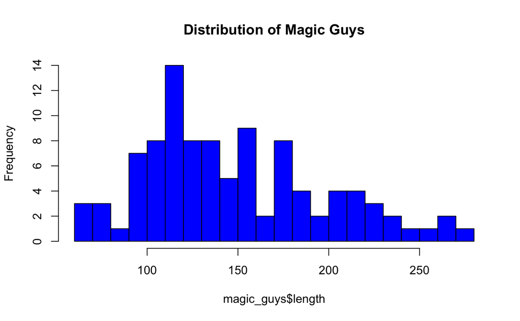

```r
# Create a basic histogram using the hist function
hist(magic_guys$length,
     main = "Distribution of Magic Guys",  # Main title of the plot
     col = "blue",                         # Color of bars
     breaks = 20)                          # Number of bins (experiment with different values)
```

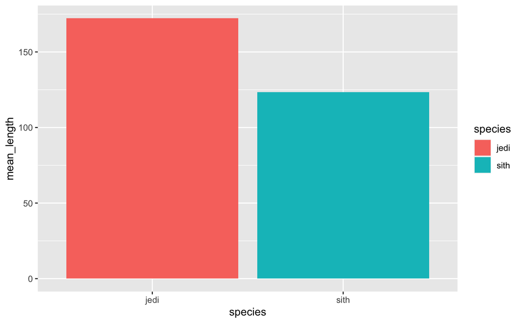

```r
# ggpplot, geom_bar, geom_histogram
data_histogram <- magic_guys %>%
  group_by(species) %>%
  summarize(mean_length = mean(length))
ggplot(data_histogram, aes(x = species, y = mean_length, angle = 45, fill= species))+ geom_bar(stat = "identity")
```

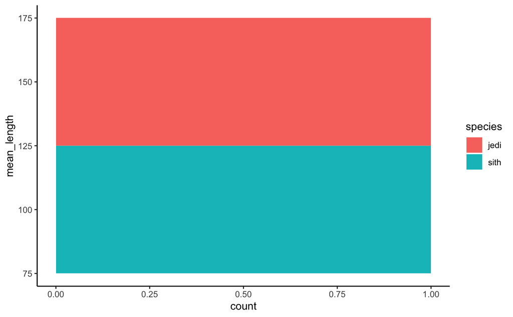

```r
ggplot(data_histogram, aes(y = mean_length, angle = 45, fill= species))+ geom_histogram(binwidth = 50)+ theme_classic()
```

2. Do the same comparison as in a. but with boxplots. If you want to use the ggplot2-package, use the functions ‘ggplot’ and ‘geom_boxplot’.

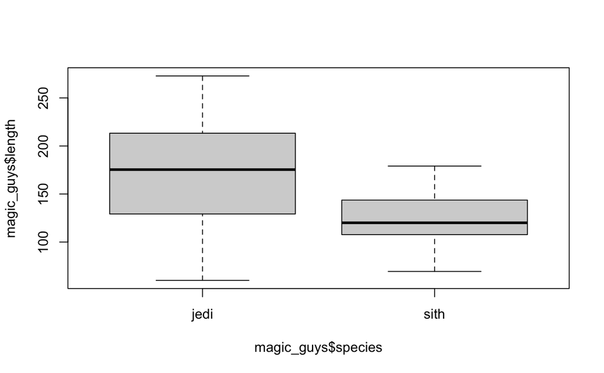

```r
boxplot(magic_guys$length~magic_guys$species)
```

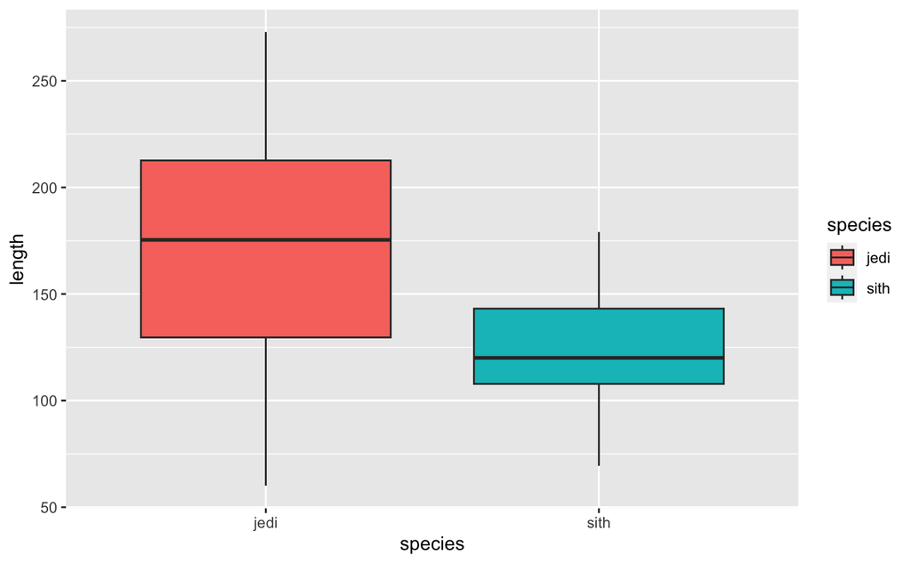

```r
# ggplot method
ggplot(magic_guys, aes(x = species, y = length, fill= species))+ geom_boxplot()
```

3. Save the plots with the ‘png’, ‘pdf’, and ‘svg’ formats. In which situation would you use which file format? ……. png for poster and presentation with high resolution, ……. pdf for printing and may be better for zoom ……. svg for interactive web application and scalable and suitable for resizing

Note: let me know if the figures doesn’t appear when you run the code so I can save and send them!

2. Load the gene expression data matrix from the ‘microarray_data.tab’ dataset

```r
# load the matrix and creat a new data frame with name microarray_matrix to avoid changing the original one
microarray_matrix<- read_table("microarray_data.tab")
```

[output not shown]

1. How big is the matrix in terms of rows and columns?

```r
nrow(microarray_matrix)
```

```
[1] 553
```

```r
ncol(microarray_matrix)
```

```
[1] 1000
```

2. Count the missing values per gene and visualize this result.

```r
# counting the missing value per gene
missing_values_per_gene <- colSums(is.na(microarray_matrix))
print(missing_values_per_gene)
```

[output not shown]

[output cut: 57 more lines]

[output not shown]

```r
# another method
# Count missing values per gene using apply function
missing_values_per_gene_new <- apply(microarray_matrix, 2, function(x) sum(is.na(x))) # it will save the result
```

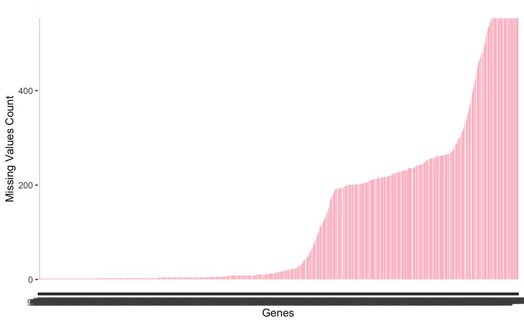

```r
# Create a data frame for plotting
missing_data_df <- data.frame(Gene = colnames(microarray_matrix), Missing_Values = missing_values_per_gene)

# Create a bar plot
ggplot(missing_data_df, aes(x = Gene, y = Missing_Values)) +
  geom_bar(stat = "identity", fill = "pink") +
  labs(x = "Genes", y = "Missing Values Count")
```

3. Find the genes for which there are more than X% (X=10%, 20%, 50%) missing values.

```r
# create a new data frame with the count of missing values in each gene
missing_data_df <- data.frame(Gene = colnames(microarray_matrix), Missing_Values = missing_values_per_gene)
# Define the threshold percentage (e.g., 10%, 20%, or 50%)
thresholds <- c(10, 20, 50)
```

```r
# Loop through each threshold percentage (10%)
for (threshold_percentage in thresholds) {
  cat("Genes with more than", 10, "% missing values:\n")
}
```

```
Genes with more than 10 % missing values:
Genes with more than 10 % missing values:
Genes with more than 10 % missing values:
```

```r
# Use subset to filter genes based on the threshold
genes_with_missing_values_more10 <- subset(missing_data_df, Missing_Values > ncol(microarray_matrix) * (10 / 100))$Gene

# Print the genes for the current threshold percentage
cat(paste(genes_with_missing_values_more10, collapse = ", "), "\n\n")
```

```
g624, g625, g626, g627, g628, g629, g630, g631, g632, g633, g634, g635, g636, g637, g638, g639, g640, g641, g642, g643, g644, g645, g646, g647, g648, g649, g650, g651, g652, g653, g654, g655, g656, g657, g658, g659, g660, g661, g662, g663, g664, g665, g666, g667, g668, g669, g670, g671, g672, g673, …
```

```r
# Loop through each threshold percentage (20%)
for (threshold_percentage in thresholds) {
  cat("Genes with more than", 20, "% missing values:\n")
}
```

```
Genes with more than 20 % missing values:
Genes with more than 20 % missing values:
Genes with more than 20 % missing values:
```

```r
# Use subset to filter genes based on the threshold
genes_with_missing_values_more20 <- subset(missing_data_df, Missing_Values > ncol(microarray_matrix) * (20/ 100))$Gene

# Print the genes for the current threshold percentage
cat(paste(genes_with_missing_values_more20, collapse = ", "), "\n\n")
```

```
g682, g683, g684, g685, g686, g687, g688, g689, g690, g691, g692, g693, g694, g695, g696, g697, g698, g699, g700, g701, g702, g703, g704, g705, g706, g707, g708, g709, g710, g711, g712, g713, g714, g715, g716, g717, g718, g719, g720, g721, g722, g723, g724, g725, g726, g727, g728, g729, g730, g731, …
```

```r
# Loop through each threshold percentage (50%)
for (threshold_percentage in thresholds) {
  cat("Genes with more than", 50, "% missing values:\n")
}
```

```
Genes with more than 50 % missing values:
Genes with more than 50 % missing values:
Genes with more than 50 % missing values:
```

```r
# Use subset to filter genes based on the threshold
genes_with_missing_values_more50 <- subset(missing_data_df, Missing_Values > ncol(microarray_matrix) * (50/ 100))$Gene

# Print the genes for the current threshold percentage
cat(paste(genes_with_missing_values_more50, collapse = ", "), "\n\n")
```

```
g937, g938, g939, g940, g941, g942, g943, g944, g945, g946, g947, g948, g949, g950, g951, g952, g953, g954, g955, g956, g957, g958, g959, g960, g961, g962, g963, g964, g965, g966, g967, g968, g969, g970, g971, g972, g973, g974, g975, g976, g977, g978, g979, g980, g981, g982, g983, g984, g985, g986, …
```

4. Replace the missing values by the average expression value for the particular gene. (Note: Imputing data has to be used with caution!)

```r
# install dplyr package
install.packages("dplyr")
library(dplyr)
library(tidyr)
```

```r
# get the mean of each column excluding NA
column_means <-lapply(microarray_matrix_2, mean, na.rm = TRUE)
View(column_means)
```

```r
# Replace NA values with column means for each column
for (col_index in 1:ncol(microarray_matrix_2)) {
  microarray_matrix_2[is.na(microarray_matrix_2[, col_index]), col_index] <- column_means[col_index]
}
View(microarray_matrix_2)
```

3. Visualize the data in the CO2 dataset in a way that gives you a deeper understanding of the data. What do you see?

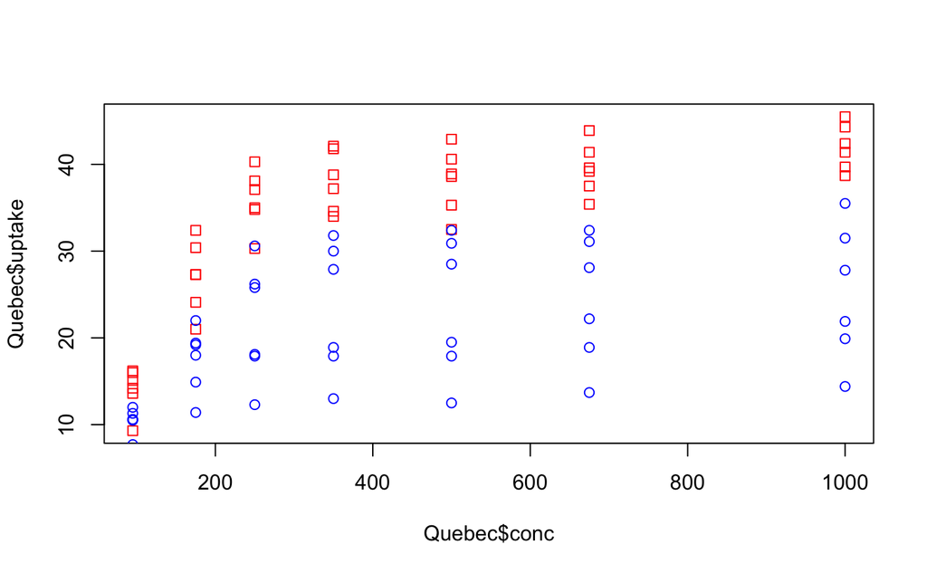

```r
View(CO2)
# comapre between species in conc and uptake of CO2
# set a new data set for each species
Quebec <- CO2[CO2$Type== "Quebec", ]
Mississippi <-  CO2[CO2$Type== "Mississippi", ]
# scatterplot for visualization of uptake level on each conc between species
plot(Quebec$uptake~Quebec$conc, col="red", pch=0) # quebec uptake increase with the increase in concentration
points(Mississippi$uptake~Mississippi$conc, col="blue", pch=1) # also positive relation between conc & uptake but lower than Quebec
```

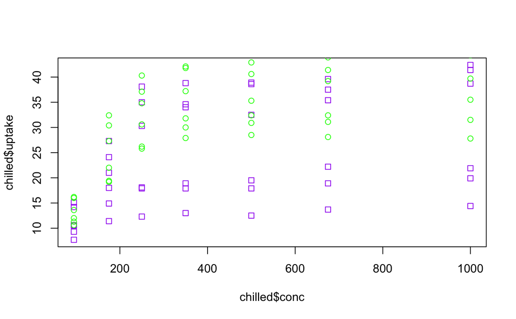

```r
# compare between the uptake in each treatment (chilled or non)
chilled <- CO2[CO2$Treatment == "chilled", ]
nonchilled <- CO2[CO2$Treatment == "nonchilled", ]
plot(chilled$uptake~chilled$conc, col="purple", pch=0)
points(nonchilled$uptake~nonchilled$conc, col="green", pch=1) # non chilled treatment show high uptake of CO2 in both species
```

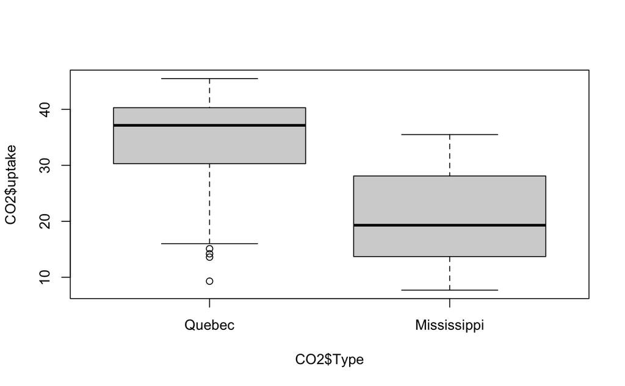

```r
# compare between  species using boxplot to know some statistical information
boxplot(CO2$uptake~CO2$Type) # more uptake in Quebec
```

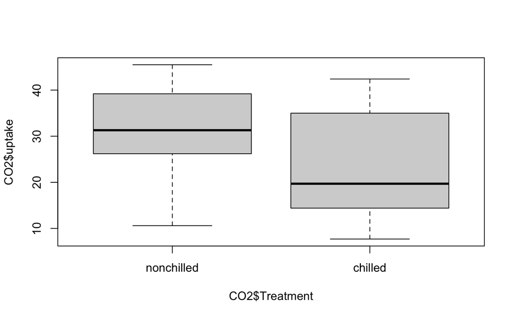

```r
boxplot(CO2$uptake~CO2$Treatment) # more uptake in nonchilled compared to cheilled in both species
```

Task 7

```r
# Install the Tidybiology package, which includes the data ‘chromosome’ and ‘proteins’
install_github("hirscheylab/tidybiology")
library(tidybiology)
```

1. Extract summary statistics (mean, median and maximum) for the following variables from the ‘chromosome’ data: variations, protein coding genes, and miRNAs. Utilize the tidyverse functions to make this as simply as possible.

```r
View(chromosome)
# summary of variations
summary(chromosome$variations)
```

```
    Min.  1st Qu.   Median     Mean  3rd Qu.     Max.
  211643  4395298  6172346  6484572  8742592 12945965
```

```r
summary(chromosome$protein_codinggenes)
```

```
   Min. 1st Qu.  Median    Mean 3rd Qu.    Max.
   71.0   595.8   836.0   850.0  1055.5  2058.0
```

```r
summary(chromosome$mi_rna)
```

```
   Min. 1st Qu.  Median    Mean 3rd Qu.    Max.
  15.00   55.75   75.00   73.17   92.00  134.00
```

2. How does the chromosome size distribute? Plot a graph that helps to visualize this by using ggplot2 package functions.

```r
# check the column names of the dataset chromosome
colnames(chromosome)
```

```
 [1] "id"                     "length_mm"              "basepairs"              "variations"
 [5] "protein_codinggenes"    "pseudo_genes"           "totallongnc_rna"        "totalsmallnc_rna"
 [9] "mi_rna"                 "r_rna"                  "sn_rna"                 "sno_rna"
[13] "miscnc_rna"             "centromereposition_mbp"
```

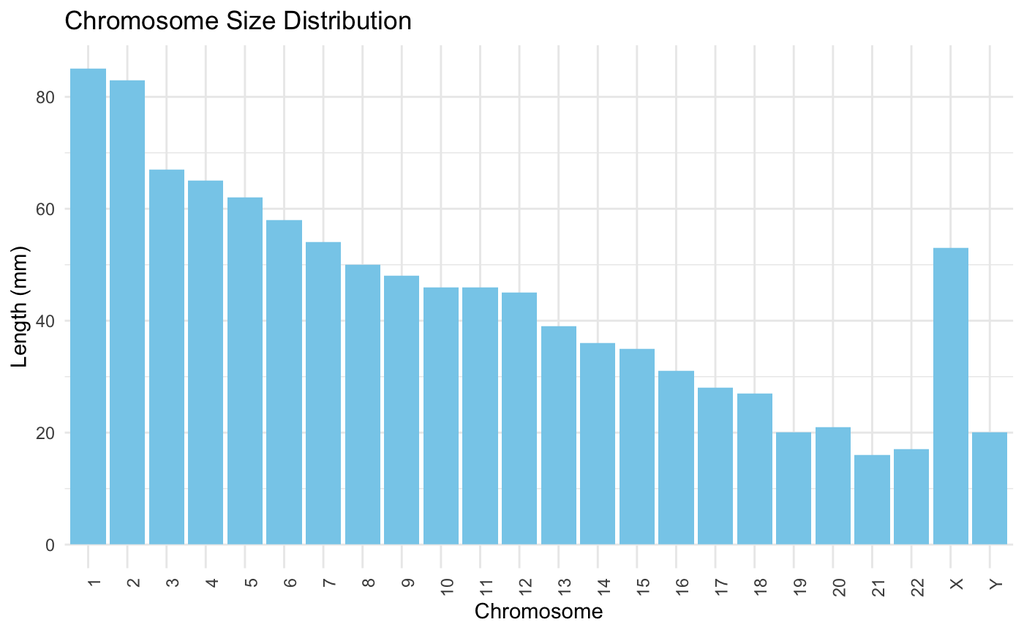

```r
# Create the bar plot
ggplot(chromosome, aes(x = id, y = length_mm)) +
  geom_bar(stat = "identity", fill = "skyblue") +
  labs(x = "Chromosome", y = "Length (mm)") +
  theme_minimal() +
  theme(axis.text.x = element_text(angle = 90, hjust = 1)) +
  ggtitle("Chromosome Size Distribution")
```

3. Does the number of protein coding genes or miRNAs correlate with the length of the chromosome? Make two separate plots to visualize these relationships.

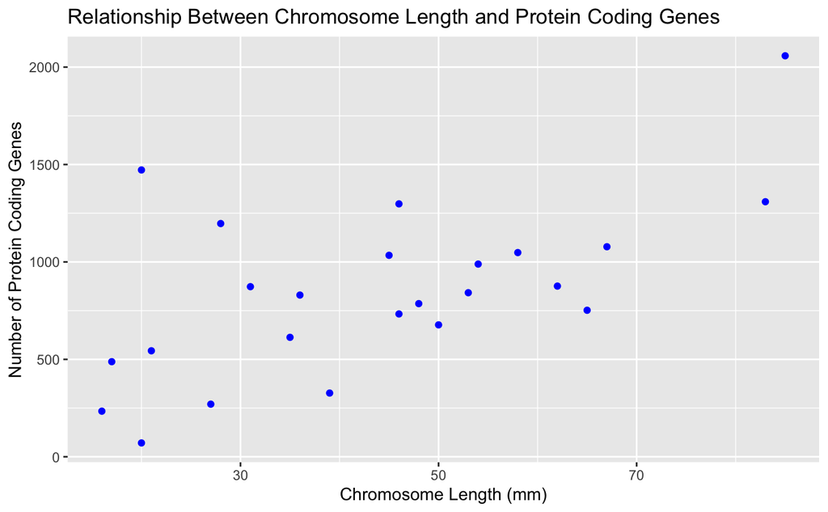

```r
# Create a scatter plot for the relationship between length and protein-coding genes
ggplot(chromosome, aes(x = length_mm, y = protein_codinggenes)) +
  geom_point(col= "blue") +
  labs(x = "Chromosome Length (mm)", y = "Number of Protein Coding Genes") +
  ggtitle("Relationship Between Chromosome Length and Protein Coding Genes")
```

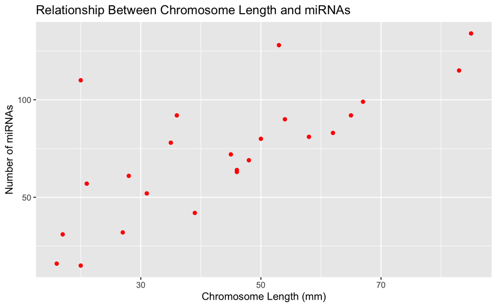

```r
# Create a scatter plot for the relationship between length and miRNAs
ggplot(chromosome, aes(x = length_mm, y = mi_rna)) +
  geom_point(col="red") +
  labs(x = "Chromosome Length (mm)", y = "Number of miRNAs") +
  ggtitle("Relationship Between Chromosome Length and miRNAs")
```

```r
# yes it correlates, number of coding genes are higher in longer chromosome
```

4. Calculate the same summary statistics for the ‘proteins’ data variables length and mass. Create a meaningful visualization of the relationship between these two variables by utilizing the ggplot2 package functions. Play with the colors, theme- and other visualization parameters to create a plot that pleases you.

```r
View(proteins)
colnames(proteins)
```

```
[1] "uniprot_id"       "gene_name"        "gene_name_alt"    "protein_name"     "protein_name_alt"
[6] "sequence"         "length"           "mass"
```

```r
# summary of variations
summary(proteins$length)
```

```
   Min. 1st Qu.  Median    Mean 3rd Qu.    Max.
    2.0   251.0   414.0   557.2   669.0 34350.0
```

```r
summary(proteins$mass)
```

```
   Min. 1st Qu.  Median    Mean 3rd Qu.    Max.
    260   27940   46140   62061   74755 3816030
```

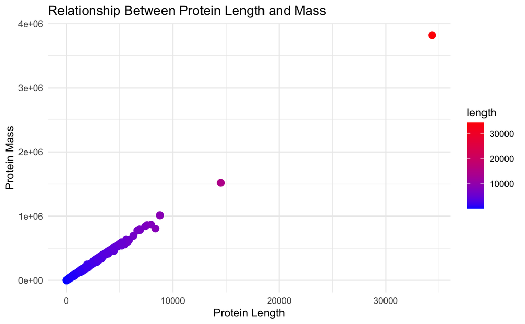

```r
# Create a scatter plot
ggplot(proteins, aes(x = length, y = mass)) +
  geom_point(aes(color = length), size = 3) +
  labs(x = "Protein Length", y = "Protein Mass") +
  scale_color_gradient(low = "blue", high = "red") +
  theme_minimal() +
  ggtitle("Relationship Between Protein Length and Mass")
```

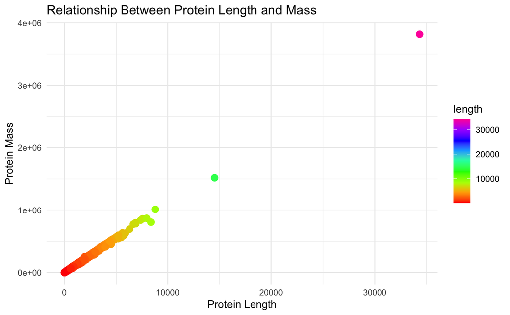

```r
# Create a scatter plot with a rainbow color scale
ggplot(proteins, aes(x = length, y = mass)) +
  geom_point(aes(color = length), size = 3) +
  labs(x = "Protein Length", y = "Protein Mass") +
  scale_color_gradientn(colors = rainbow(9)) +  # Adjust the number of colors as needed
  theme_minimal() +
  ggtitle("Relationship Between Protein Length and Mass")
```

Note: can we ignore the last value to make the graph more spread, what do you think?

Best luck ^_^